# Habituation Data - Background and Analysis Notes

Laura Brubaker-Wittman

10/28/2021

# Background

This project investigate the process of habituation in Bornean orangutans in Gunung Palung National Park in West Kalimantan, Borneo, Indonesia. Specifically, it explores questions regarding orangutan behaviors during habituation, viewing these as strategies employed by the orangutan to evade humans until they become more habituated to our presence. These strategies include *hiding,* *vocalizing,* and *traveling.* Specifically, we look at the differences in these strategies between age-sex classes (e.g. ung=flanged males, adolescent females, etc.), and in the presence of offspring or other conspecifics. Furthermore, these strategies employ different levels of energy expenditure (i.e. traveling is more energetically costly than hiding). We explore if fruit availability at the time of habituation impacts which strategy is employed by orangutans, as part of a trade off decision as proposed by life history theory.

## Research Questions

This research asks the following questions:

1. Can we determine, based on percentage of time spent in specific activities and behaviors, if orangutans are habituated or not?
2. Is there a difference in strategies employed by the various age-sex classes?
3. Do mothers with offspring employ different strategies than when they are without offspring?
4. Does the presence of conspecifics that are not offspring impact which strategy is used?
5. Does fruit availability impact the strategy employed?

## Sub-sampling Data and Exclusion Criteria

Since hiding, traveling, and vocalizing are all normal parts of an orangutan’s behavioral repertoire, we first had to determine cutoffs for percentage of time spent in these behaviors that would indicate an excessive percentage of amount of time (or lack thereof) spent in one of these activities. If an orangutan’s percentage of time spent in oen of these behaviors is outside of these cutoffs for the range of “habituated” behavior, then we can assume that individual orangutan is unhabituated and furthermore, is using one or more strategies to evade humans.

In order to create a sub-sample of the data that we could use to create the ranges for percentage of time spent in specific activities for habituated orangutans, we first had to determine exclusion criteria to ensure we were not including unhabituated behavior data in the creation of these ranges.

**Exclusion Criteria:**

*Exclude if:*

1. The follow is one of the first ten (10) days that a specific orangutan is being followed, *unless they are already marked as habituated during the entirety of those first ten days. This happens when an orangutan changes age-sex class, or if they were previously unidentified, became habituated, and were then given a name.*
2. The follow is after a six- (6) or more month gap from the previous follow series. *Exclude this entire follow series.*
3. The follow has a vocalization score of 4 or higher (out of 10).
4. The follow is less than 4 hours long (240 minues).
5. The follow does not fit any of the other criteria but both the field assessment and statistical reassessment of the data indicates that the animal is unhabituated for another reason.

By enacting this exclusion criteria to only include days we can conservatively say an individual orangutan is habituated, we can use this sub-sample to create ranges of “normal” or “habituated” percentage of time spent in specific activities.

## Analyzing “Habituated” Sub-Sample to Create Behavior Ranges and Cutoffs

In this section, I will go through the steps taken in *FileMaker*, *Excel*, and *R* to find averages and standard deviations (with more than 2 standard deviations being the cutoffs) for habituated orangutan behavior by age-sex class.

1. Once each follow day was marked as *Included* or *Excluded* following the exclusion criteria laid out above, the data for the Included follow days was extracted from FileMaker into an Excel spreadsheet.
2. These data were uploaded into R.
1. Unflanged Males spreadsheet was cleaned and prepped for R. This included removing spaces in any fields, shortening field names, and adjusting for all numbers to have two places after a decimal point (to the hundredths place).
2. Using the {readxl} package, I imported the data into R for Unflanged Males

```r
library("readxl")
require(readxl)
d <- read_excel("28-10-2021 - Unflanged Males Export - 24 Oct 2021 - LBW Cleanup.xlsx", sheet = 1, col_names = TRUE) #I only had to put in the name of the file since it is in my working directory.
head(d)
```

```
## # A tibble: 6 x 10
##   Follow.Number Date                Nama.OH Percent.time.feed~ Percent.time.sle~
##           <dbl> <dttm>              <chr>                <dbl>             <dbl>
## 1          7053 2016-05-20 00:00:00 Bilbo                 60.8              35.4
## 2          7054 2016-05-21 00:00:00 Bilbo                 62.6              30.7
## 3          7055 2016-05-22 00:00:00 Bilbo                 33.1              54.3
## 4          7056 2016-05-23 00:00:00 Bilbo                 72.4              20.0
## 5          7057 2016-05-24 00:00:00 Bilbo                 44.9              50.3
## 6          7685 2018-06-29 00:00:00 Bilbo                 52.3              39.9
## # ... with 5 more variables: Percent.time.rest <dbl>, Percent.tim.travel <dbl>,
## #   Total.vocalizations <dbl>, Vocalization.Group <dbl>,
## #   Vocalization.per.time.awake <dbl>
```

3. Before performing other analyses, I want to make sure the data I am using looks like a normal distribution, since I will be using this assumption with two standard deviations from the average working as my cutoffs.Due to the central limit theorem and my large dataset, I am not worried about this, but it also is nice just to see the way the data looks.

```r
library(ggpubr)
library(dplyr)
```

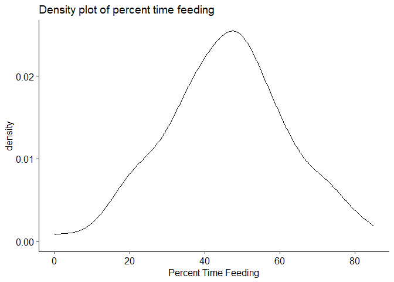

```r
ggdensity(d$Percent.time.feeding,
          main = "Density plot of percent time feeding",
          xlab = "Percent Time Feeding")
```

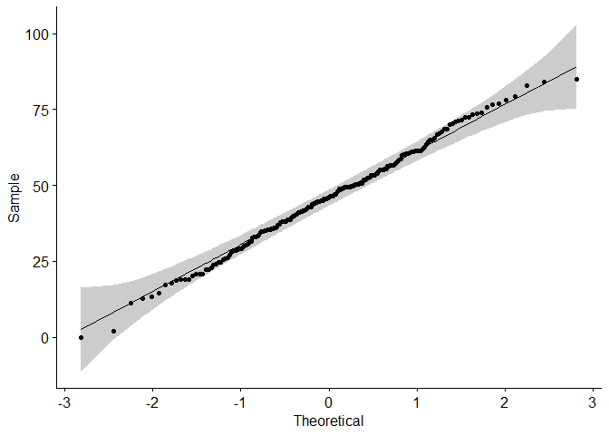

```r
ggqqplot(d$Percent.time.feeding)
```

```r
shapiro.test(d$Percent.time.feeding)
```

```
##
##  Shapiro-Wilk normality test
##
## data:  d$Percent.time.feeding
## W = 0.99591, p-value = 0.8635
```

The results of all of these tests show that my “Percentage of Time Spent Feeding” data is normally distributed. Let’s check the other data as well.

**Percentage of Time Spent Sleeping**

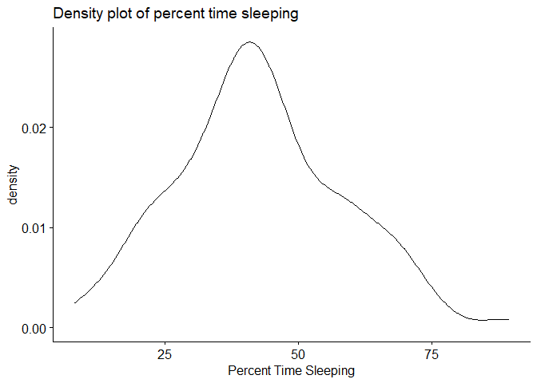

```r
ggdensity(d$Percent.time.sleep,
          main = "Density plot of percent time sleeping",
          xlab = "Percent Time Sleeping")
```

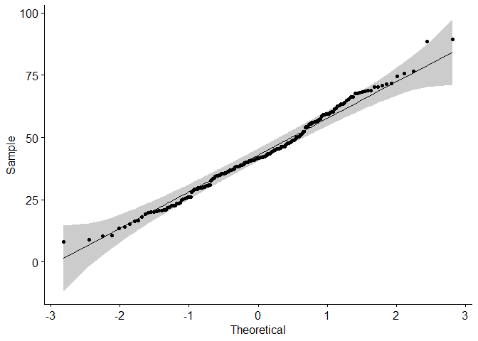

```r
ggqqplot(d$Percent.time.sleep)
```

```r
shapiro.test(d$Percent.time.sleep)
```

```
##
##  Shapiro-Wilk normality test
##
## data:  d$Percent.time.sleep
## W = 0.98941, p-value = 0.137
```

**Percentage of Time Spent Resting**

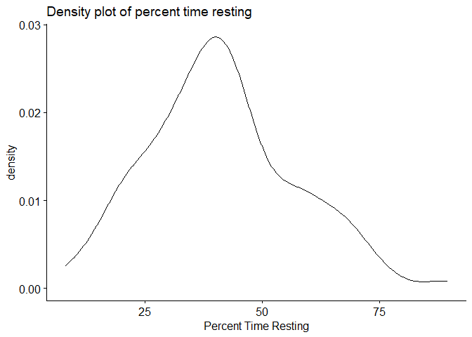

```r
ggdensity(d$Percent.time.rest,
          main = "Density plot of percent time resting",
          xlab = "Percent Time Resting")
```

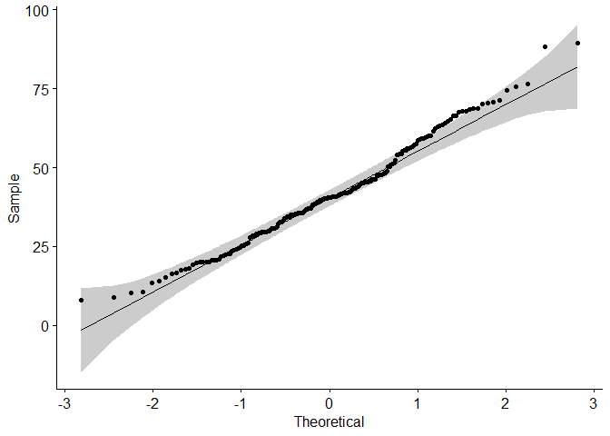

```r
ggqqplot(d$Percent.time.rest)
```

```r
shapiro.test(d$Percent.time.rest)
```

```
##
##  Shapiro-Wilk normality test
##
## data:  d$Percent.time.rest
## W = 0.98394, p-value = 0.02009
```

**Percent Time Traveling**

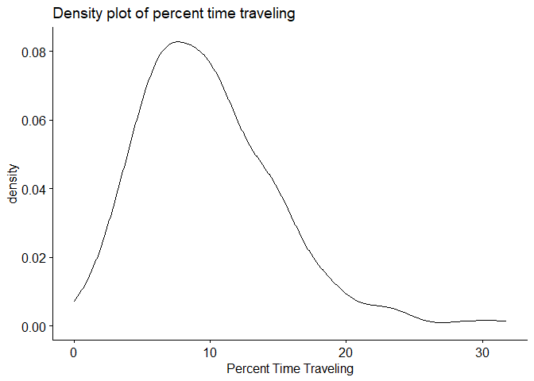

```r
ggdensity(d$Percent.tim.travel,
          main = "Density plot of percent time traveling",
          xlab = "Percent Time Traveling")
```

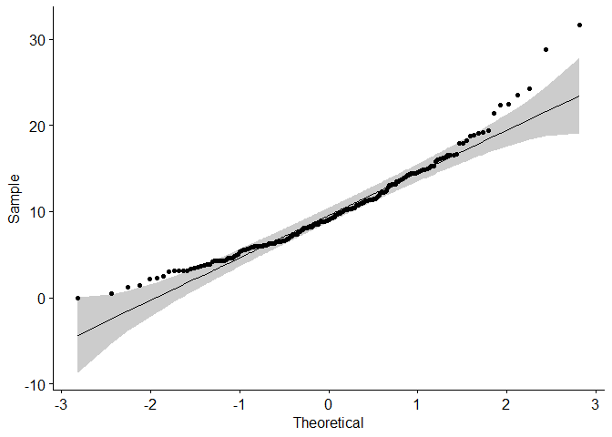

```r
ggqqplot(d$Percent.tim.travel)
```

```r
shapiro.test(d$Percent.tim.travel)
```

```
##
##  Shapiro-Wilk normality test
##
## data:  d$Percent.tim.travel
## W = 0.94853, p-value = 1.097e-06
```

**Percentage of time Vocalizing**

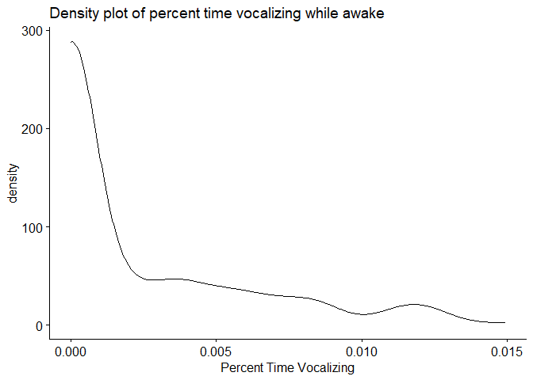

```r
ggdensity(d$Vocalization.per.time.awake,
          main = "Density plot of percent time vocalizing while awake",
          xlab = "Percent Time Vocalizing")
```

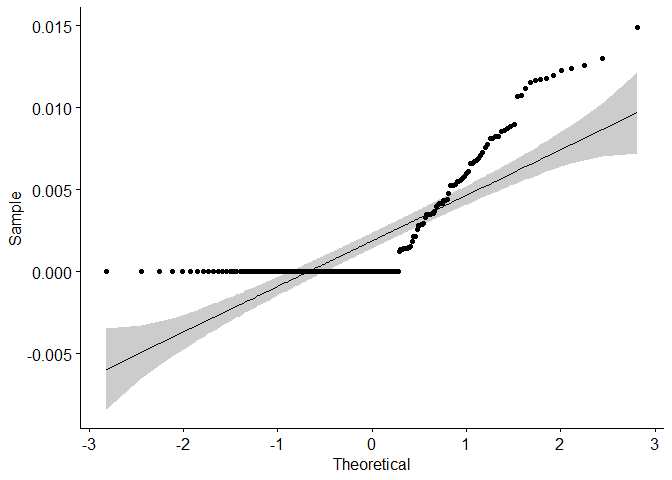

```r
ggqqplot(d$Vocalization.per.time.awake)
```

```r
shapiro.test(d$Vocalization.per.time.awake)
```

```
##
##  Shapiro-Wilk normality test
##
## data:  d$Vocalization.per.time.awake
## W = 0.68938, p-value < 2.2e-16
```

After running my tests, it looks like a few of these are not normal distributions. So instead of finding standard deviation for those, I will use percentiles to the equal percentiles represented by standard deviation, 2.5% and 97.5% respectively. The one belows is for Percent Time Vocalizing while awake. This one is difficult because this are very low numbers.

```r
quantile(d$Vocalization.per.time.awake, c(.025, .975))
```

```
##       2.5%      97.5%
## 0.00000000 0.01195073
```

Or, we can see if a log transformation would be more useful.

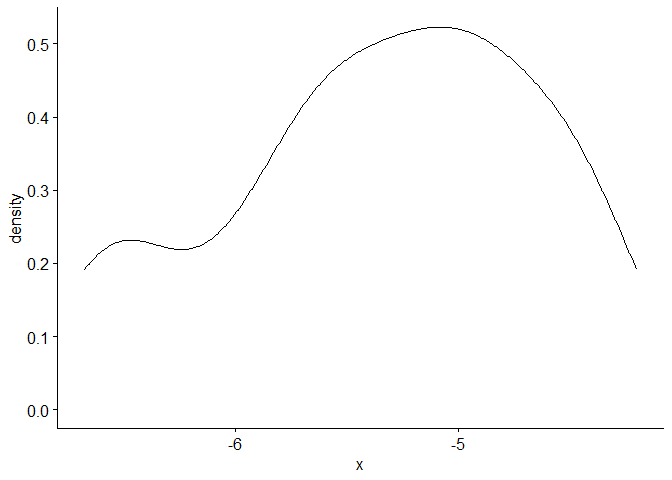

```r
VocalLog <- log(d$Vocalization.per.time.awake)
ggdensity(VocalLog)
```

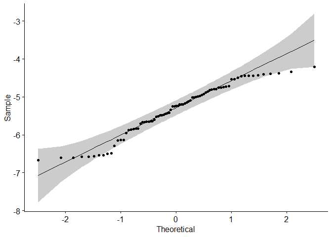

```r
ggqqplot(VocalLog)
```

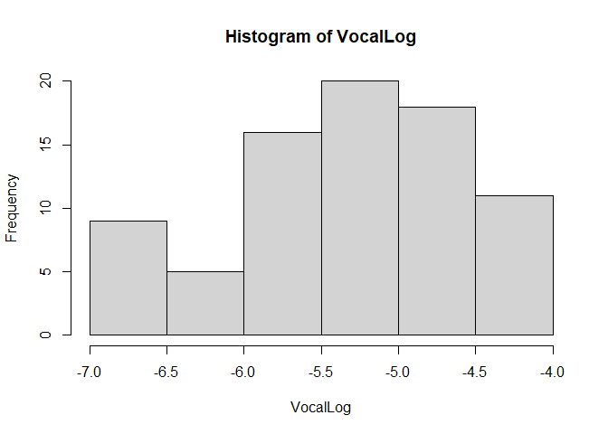

```r
hist(VocalLog)
```

This looks much better. Not sure if it is useful though? Maybe we try a different variable for vocalizations?

Instead, let’s go back to one of the other variables to see if we can find cutoffs. I am most interested in time traveling, so let’s try that. Looking at the statistics we ran above, the distribution is not quite normal, with a positive skew. Let’s see what we can get for the 2.5% and 97.5% percentiles.

```r
quantile(d$Percent.tim.travel, c(.025, .975))
```

```
##      2.5%     97.5%
##  2.314539 22.333149
```

Let’s go ahead and use these as our cutoffs for traveling.

Next, let’s do time spent resting, which includes time asleep (which means we probably won’t need the sleeping data for now).

Time resting looks closer to normal, though the Shapiro test says it isn’t quite. Let’s do percentiles and standard deviations and see what we get.

```r
quantile(d$Percent.time.rest, c(.025, .975))
```

```
##     2.5%    97.5%
## 14.05958 71.41201
```

```r
sd (d$Percent.time.rest)
```

```
## [1] 15.64884
```

```r
max(d$Percent.time.rest) - sd (d$Percent.time.rest)
```

```
## [1] 73.79753
```

Looks like they are pretty close! Because it is slightly skewed, I will use the cutoffs from using the percentiles.

Even though eating is not a strategy per se, I do want to see if they are eating less when they are unhabituated due to traveling more, additional stress from our presence, etc. So let’s do all of our descriptive stats for that as well.

**Percent Time Eating**

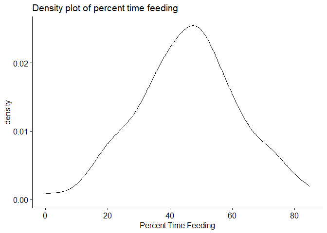

```r
ggdensity(d$Percent.time.feeding,
          main = "Density plot of percent time feeding",
          xlab = "Percent Time Feeding")
```

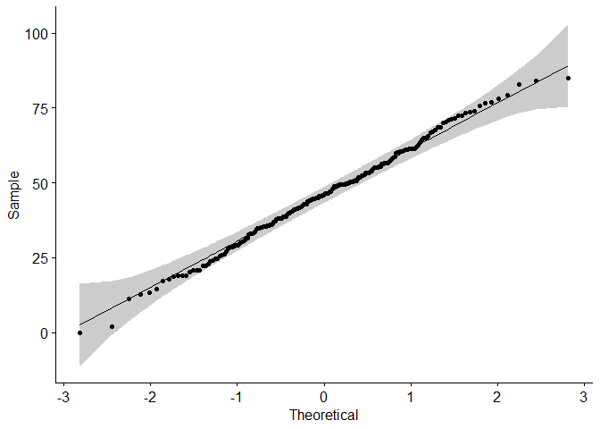

```r
ggqqplot(d$Percent.time.feeding)
```

```r
shapiro.test(d$Percent.time.feeding)
```

```
##
##  Shapiro-Wilk normality test
##
## data:  d$Percent.time.feeding
## W = 0.99591, p-value = 0.8635
```

This data looks normally distributed and this is confirmed by the Shapiro-Wilk test. Yay! Now let’s find the standard deviations/percentiles for our cutoffs.

```r
sd (d$Percent.time.feeding)
```

```
## [1] 16.20403
```

```r
max(d$Percent.time.feeding) - sd (d$Percent.time.feeding)
```

```
## [1] 68.65564
```

Great! So my next step is to go through all of the *Excluded* follows in Filemaker, which should be conservatively demonstrating the follows during which an individual was unhabituated and use these cutoffs to see which strategies they might be using. Perhaps for vocalizing, it can just be if it is four or more for the vocalizaton score since that was our cutoff for the exclusion criteria?

Here is a table with the cutoffs for unflanged males:

```r
UFM_Cutoff<- read_excel("28-10-2021 - Percentage in Behavior Cutoffs for UFM.xlsx", sheet = 1, col_names = TRUE)
UFM_Cutoff
```

[output not shown]

## Flanged Males

Let’s do the same thing above for flanged males and adult females. First, we will import the data from Excel.

```r
FM <- read_excel("28-10-2021 - Flanged Males Export - 24 Oct 2021 - LBW Cleanup.xlsx", sheet = 1, col_names = TRUE)
head(FM)
```

```
## # A tibble: 6 x 10
##   Follow.Number Date                Nama.OH Percent.time.feed~ Percent.time.sle~
##           <dbl> <dttm>              <chr>                <dbl>             <dbl>
## 1          6748 2015-04-12 00:00:00 Alfred                63.6              32.6
## 2          6749 2015-04-13 00:00:00 Alfred                64.5              31.2
## 3          6751 2015-04-14 00:00:00 Alfred                35.0              59.7
## 4          6754 2015-04-15 00:00:00 Alfred                66.1              28.7
## 5          6904 2015-12-01 00:00:00 Alfred                75.8              15.6
## 6          6905 2015-12-02 00:00:00 Alfred                49.8              34.6
## # ... with 5 more variables: Percent.time.rest <dbl>,
## #   Percent.time.travel <dbl>, Total.Vocalizations <dbl>,
## #   Vocalization.Group <dbl>, Vocalization.per.time.awake <dbl>
```

Next, we will check the normality of traveling, resting, and feeding.

**Percent Time Traveling**

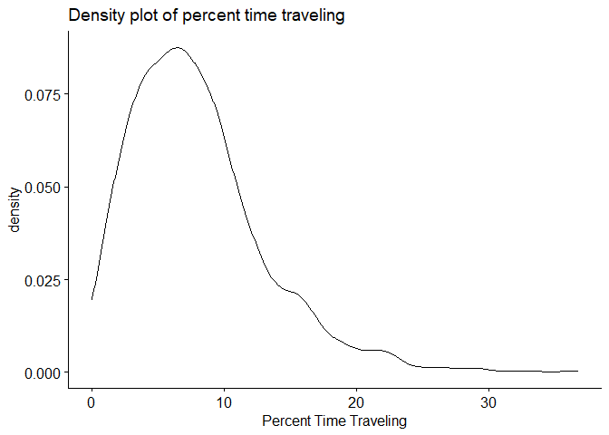

```r
ggdensity(FM$Percent.time.travel,
          main = "Density plot of percent time traveling",
          xlab = "Percent Time Traveling")
```

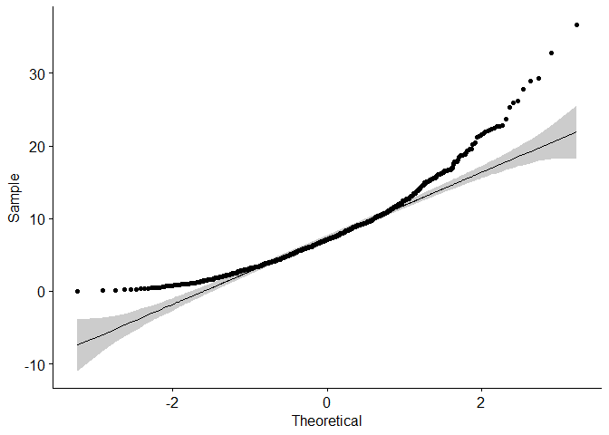

```r
ggqqplot(FM$Percent.time.travel)
```

```r
shapiro.test(FM$Percent.time.travel)
```

```
##
##  Shapiro-Wilk normality test
##
## data:  FM$Percent.time.travel
## W = 0.92159, p-value < 2.2e-16
```

It’s skewed, so we will use percentiles.

```r
quantile(FM$Percent.time.travel, c(.025, .975))
```

```
##       2.5%      97.5%
##  0.8393244 21.1998804
```

Great, now I will move on to percentage of time spent resting during a follow.

**Percent Time Resting**

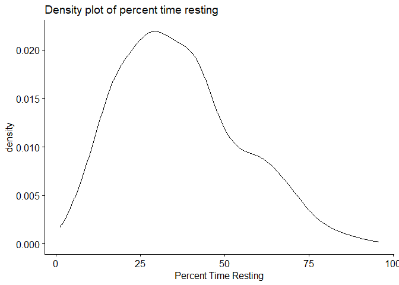

```r
ggdensity(FM$Percent.time.rest ,
          main = "Density plot of percent time resting",
          xlab = "Percent Time Resting")
```

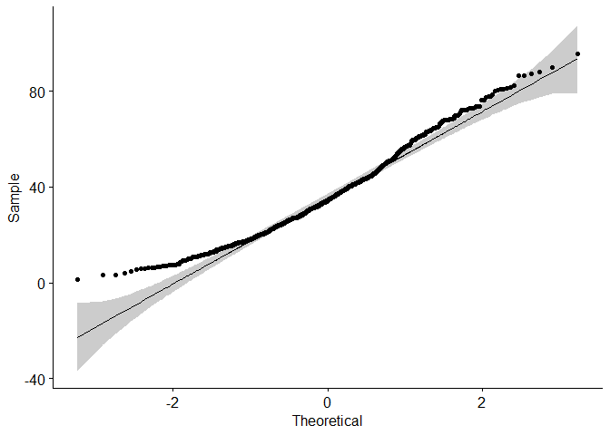

```r
ggqqplot(FM$Percent.time.rest)
```

```r
shapiro.test(FM$Percent.time.rest)
```

```
##
##  Shapiro-Wilk normality test
##
## data:  FM$Percent.time.rest
## W = 0.97373, p-value = 4.511e-11
```

Let’s do percentiles for this one as well.

```r
quantile(FM$Percent.time.rest, c(.025, .975))
```

```
##      2.5%     97.5%
##  7.688011 73.526011
```

Ok, now for feeding!

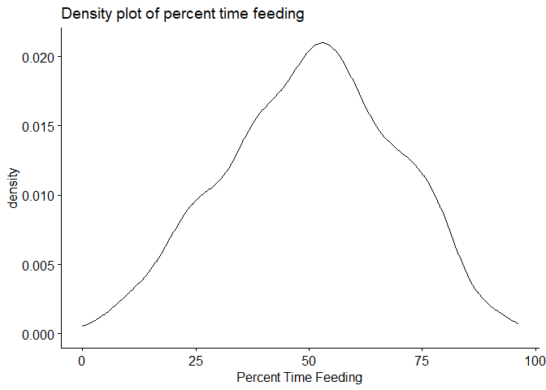

```r
ggdensity(FM$Percent.time.feeding ,
          main = "Density plot of percent time feeding",
          xlab = "Percent Time Feeding")
```

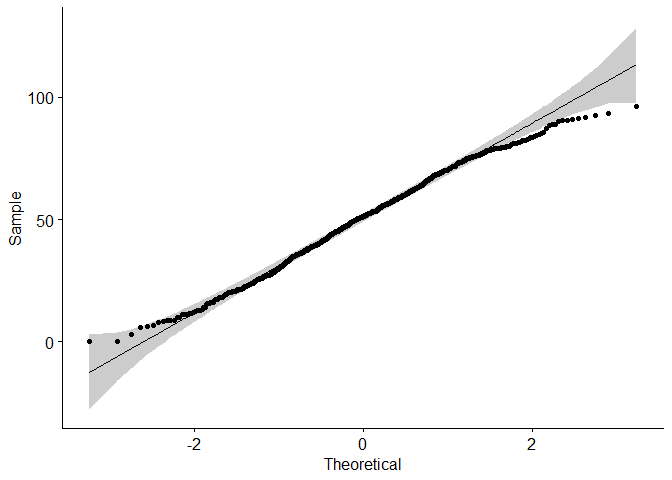

```r
ggqqplot(FM$Percent.time.feeding)
```

```r
shapiro.test(FM$Percent.time.feeding)
```

```
##
##  Shapiro-Wilk normality test
##
## data:  FM$Percent.time.feeding
## W = 0.99264, p-value = 0.0003941
```

The distribution for time spent feeding is actually pretty normal! Let’s do both SD and percentiles to see how close they are…

```r
quantile(FM$Percent.time.feeding, c(.025, .975))
```

```
##     2.5%    97.5%
## 12.83799 82.99562
```

```r
sd (FM$Percent.time.feeding)
```

```
## [1] 18.7252
```

```r
max(FM$Percent.time.feeding) - sd (FM$Percent.time.feeding)
```

```
## [1] 77.35323
```

Hmmmmm… they are close but a bit different. And it looks like it did not “pass” the Shapiro-Wilks normality test. So, le’ts use the percentiles as cut-offs.

As with the unflanged males, we will use a vocalization score of 4 or above for our cut-off.

Here is a chart with our cutoffs for flanged males:

```r
FM_Cutoff<- read_excel("28-10-2021 - Percentage in Behavior Cutoffs for FM.xlsx", sheet = 1, col_names = TRUE)
FM_Cutoff
```

```
## # A tibble: 4 x 3
##   `Behavior/Activity` `Low-end Cutoff (2.5th Percentile)` `High-end Cutoff (97.~
##   <chr>               <chr>                                                <dbl>
## 1 Traveling           0.84                                                  21.2
## 2 Resting             7.69                                                  73.5
## 3 Vocalizing          N/A                                                    4
## 4 Feeding             12.84                                                 83.0
```

And last but not least, I will do the same for adult females.

First, let’s import the cleaned up data. This includes removing data for Jumi, as she has never given birth. Adult females include all females who have given birth (versus nulliparous adolescents). As with the others, I also deleted rows that had zeros for all data, as these should be excluded from the analysis.

```r
AF <- read_excel("28-10-2021 - Adult Females Export - 24 Oct 2021 - LBW Cleanup.xlsx", sheet = 1, col_names = TRUE)
head(AF)
```

```
## # A tibble: 6 x 11
##   Follow.Number Date                Nama.OH Mother.Class Percent.time.feeding
##           <dbl> <dttm>              <chr>   <chr>                       <dbl>
## 1          5784 2012-04-20 00:00:00 Asny    Inf ind juv                  20
## 2          6303 2013-12-26 00:00:00 Asny    Inf ind juv                  52.1
## 3          6306 2013-12-27 00:00:00 Asny    Inf ind juv                  72.2
## 4          6308 2013-12-28 00:00:00 Asny    Inf ind juv                  70.2
## 5          6310 2013-12-29 00:00:00 Asny    Inf ind juv                  72.9
## 6           383 1995-04-23 00:00:00 Beth    No infant                    21.7
## # ... with 6 more variables: Percent.time.sleep <dbl>, Percent.time.rest <dbl>,
## #   Percent.time.travel <dbl>, Total.Vocalizations <dbl>,
## #   Vocalization.Group <dbl>, Vocalization.per.time.awake <dbl>
```

Looks good! Now let’s find our cutoffs.

**Percent Time Traveling**

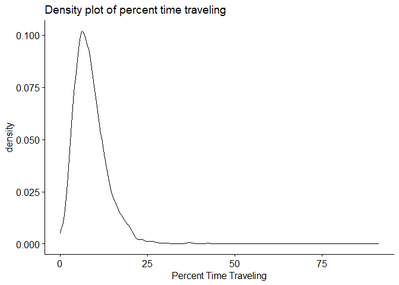

```r
ggdensity(AF$Percent.time.travel,
          main = "Density plot of percent time traveling",
          xlab = "Percent Time Traveling")
```

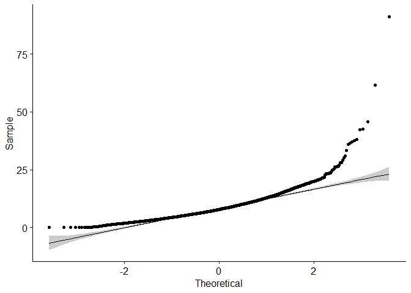

```r
ggqqplot(AF$Percent.time.travel)
```

```r
shapiro.test(AF$Percent.time.travel)
```

```
##
##  Shapiro-Wilk normality test
##
## data:  AF$Percent.time.travel
## W = 0.84139, p-value < 2.2e-16
```

Very skewed! So let’s find percentiles.

```r
quantile(AF$Percent.time.travel, c(.025, .975))
```

```
##      2.5%     97.5%
##  1.927138 19.814663
```

Now on to percent time resting!

**Percent Time Resting**

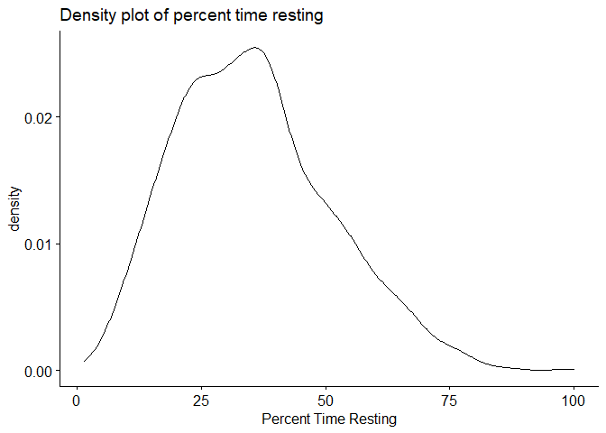

```r
ggdensity(AF$Percent.time.rest ,
          main = "Density plot of percent time resting",
          xlab = "Percent Time Resting")
```

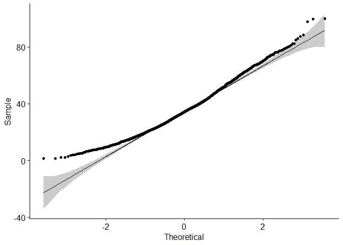

```r
ggqqplot(AF$Percent.time.rest)
```

```r
shapiro.test(AF$Percent.time.rest)
```

```
##
##  Shapiro-Wilk normality test
##
## data:  AF$Percent.time.rest
## W = 0.98087, p-value < 2.2e-16
```

Skewed again! Let’s check the percentiles.

```r
quantile(AF$Percent.time.rest, c(.025, .975))
```

```
##      2.5%     97.5%
##  9.751305 69.210326
```

Next up: Percent time feeding

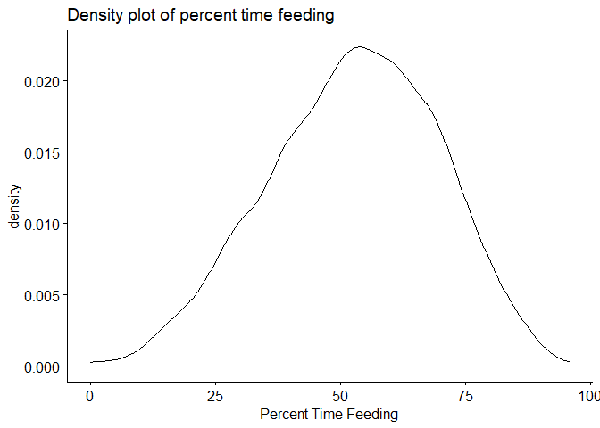

```r
ggdensity(AF$Percent.time.feeding ,
          main = "Density plot of percent time feeding",
          xlab = "Percent Time Feeding")
```

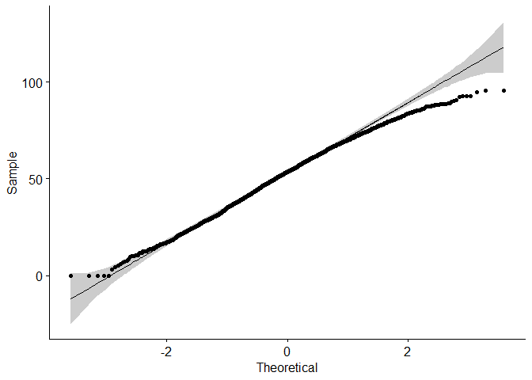

```r
ggqqplot(AF$Percent.time.feeding)
```

```r
shapiro.test(AF$Percent.time.feeding)
```

```
##
##  Shapiro-Wilk normality test
##
## data:  AF$Percent.time.feeding
## W = 0.99324, p-value = 2.378e-10
```

Perhaps closer to normal, but let’s do percentiles.

```r
quantile(AF$Percent.time.feeding, c(.025, .975))
```

```
##     2.5%    97.5%
## 17.65051 83.15107
```

All done for adult females! And here is the cutoff chart:

```r
AF_Cutoff<- read_excel("28-10-2021 - Percentage in Behavior Cutoffs for AF.xlsx", sheet = 1, col_names = TRUE)
AF_Cutoff
```

```
## # A tibble: 4 x 3
##   `Behavior/Activity` `Low-end Cutoff (2.5th Percentile)` `High-end Cutoff (97.~
##   <chr>               <chr>                                                <dbl>
## 1 Traveling           1.93                                                  19.8
## 2 Resting             9.75                                                  69.2
## 3 Vocalizing          N/A                                                    4
## 4 Feeding             17.649999999999999                                    83.2
```